# VoteMatch - Modeling

### Load Data

```r
rm(list = ls())
library(dplyr)
library(xgboost)
library(caret)

#load("preprocessed_data.RData")
load("scripts/preprocessed_data_2.RData")
```

### Handling Missing Values

We first remove columns with a high proportion of missing values (more than 4,000 missing entries out of ~15,000 rows). These columns are unlikely to contribute meaningfully to the model and may even introduce noise.

```r
na_counts <- sapply(ces_Modeling, function(x) sum(is.na(x)))
high_na_cols <- names(na_counts[na_counts > 4000])

modeling_var_clean <- ces_Modeling %>%
  select(-all_of(high_na_cols))

summary(modeling_var_clean)
```

```
##             cps21_fed_gov_sat          pes21_province
##  Fairly satisfied    :5682    Ontario         :4298
##  Not at all satisfied:4498    Quebec          :3647
##  Not very satisfied  :3792    Alberta         :1496
##  Very satisfied      :1275    British Columbia:1355
##  NA's                : 136    Manitoba        : 459
##                               (Other)         : 947
##                               NA's            :3181
##                     pes21_govtcare                pes21_donerm
##  Neither agree nor disagree:2217   About the same as now:4328
##  Somewhat agree            :4378   Much less            : 583
##  Somewhat disagree         :1857   Much more            :2295
##  Strongly agree            :3291   Somewhat less        : 937
##  Strongly disagree         : 330   Somewhat more        :3628
##  NA's                      :3310   NA's                 :3612
##
##                    pes21_envirojob                  pes21_equalrights
##  Neither agree nor disagree:2623   Neither agree nor disagree:2308
##  Somewhat agree            :2705   Somewhat agree            :1972
##  Somewhat disagree         :3391   Somewhat disagree         :2924
##  Strongly agree            :1665   Strongly agree            :1212
##  Strongly disagree         :1602   Strongly disagree         :3597
##  NA's                      :3397   NA's                      :3370
##
##                    pes21_famvalues                     pes21_fitin
##  Neither agree nor disagree:2561   Neither agree nor disagree:2007
##  Somewhat agree            :3223   Somewhat agree            :3053
##  Somewhat disagree         :1856   Somewhat disagree         :2511
##  Strongly agree            :2502   Strongly agree            :2039
##  Strongly disagree         :1790   Strongly disagree         :2150
##  NA's                      :3451   NA's                      :3623
##
##         pes21_inequal                     pes21_privjobs
##  Definitely not: 325   Neither agree nor disagree:2218
##  Definitely yes:4489   Somewhat agree            :1985
##  Not sure      :1507   Somewhat disagree         :4569
##  Probably not  :1058   Strongly agree            : 663
##  Probably yes  :4643   Strongly disagree         :2147
##  NA's          :3361   NA's                      :3801
##
```

[output cut: 17 more lines]

```
##  No  : 2197          Divorced             :1201   Min.   :18.00
##  Yes :13168          Living with a partner:2485   1st Qu.:39.00
##  NA's:   18          Married              :7258   Median :55.00
##                      Never Married        :3331   Mean   :52.88
##                      Separated            : 424   3rd Qu.:67.00
##                      Widowed              : 598   Max.   :97.00
##                      NA's                 :  86
##               votechoice
##  Bloc Québécois    :1801
##  Conservative Party:4412
##  Green Party       : 350
##  Liberal Party     :5019
##  NDP               :3297
##  People's Party    : 504
##
```

Since XGBoost natively supports missing values and handles them automatically during training and prediction. It learns the optimal split direction for `NA`s during tree building, so there’s no need for imputation or row deletion.

### Data Split

The dataset was split into two groups:

- *train_data*: Training set (80%), used to train the model.
- *test_data*: Testing set (20%), used to evaluate the model’s performance.

```r
set.seed(123)
train_index <- sample(seq_len(nrow(modeling_var_clean)), size = 0.8 * nrow(modeling_var_clean))
train_data <- modeling_var_clean[train_index, ]
test_data <- modeling_var_clean[-train_index, ]
```

### Model Selection

We experimented with several modeling approaches, including **logistic regression** and **random forest**, but found that both struggled to accurately predict smaller political parties such as the Green Party and the People’s Party.

After these initial trials, we chose to use **XGBoost**, which provided several advantages:

- Can handle **imbalanced data** well using class weights.
- Supports **missing values** without needing imputation.
- Performs well for **multi-class classification**.

With tuning and weighting, XGBoost gave more balanced results across all parties.

### Data Preparation

```r
# Convert factor columns to numeric (using your original approach)
train_data_numeric <- train_data %>% mutate_if(is.factor, as.numeric)
test_data_numeric  <- test_data %>% mutate_if(is.factor, as.numeric)

# Define feature columns (exclude 'votechoice')
features <- setdiff(names(train_data_numeric), "votechoice")

# Create feature matrices for train and test
train_matrix <- as.matrix(train_data_numeric[, features])
test_matrix  <- as.matrix(test_data_numeric[, features])

# Create labels
train_label <- as.numeric(train_data_numeric$votechoice) - 1
test_label  <- as.numeric(test_data_numeric$votechoice) - 1

# Compute sample weights
class_counts <- table(train_data_numeric$votechoice)
total_count  <- sum(class_counts)
n_class      <- length(class_counts)

# Class weight = total / (num_classes * class_frequency)
class_weights_map <- total_count / (n_class * class_counts)
sample_weights <- class_weights_map[ as.character(train_data_numeric$votechoice) ]

# Build XGBoost DMatrix
dtrain <- xgb.DMatrix(data = train_matrix, label = train_label, weight = sample_weights)
dtest  <- xgb.DMatrix(data = test_matrix,  label = test_label)
```

### XGBoost - Training

We trained the model using the `xgb.train()` function with a fixed number of boosting rounds. A helper function `train_and_evaluate()` was created to:

- Train the model
- Predict class labels on the test set
- Return a confusion matrix for evaluation

```r
train_and_evaluate <- function(params, dtrain, dtest, nrounds) {
  # Train model
  model <- xgb.train(
    params  = params,
    data    = dtrain,
    nrounds = nrounds,
    verbose = 0
  )

  # Predict probabilities
  pred_prob <- predict(model, newdata = dtest)

  # Convert to matrix and get class with max probability
  pred_mat  <- matrix(pred_prob, ncol = n_class, byrow = TRUE)
  pred_idx  <- max.col(pred_mat) - 1

  # Convert back to factor labels
  pred_labels <- factor(pred_idx, levels = 0:(n_class-1), labels = levels(train_data$votechoice))

  # Generate confusion matrix
  cm <- confusionMatrix(pred_labels, test_data$votechoice)

  return(list(model = model, pred = pred_labels, cm = cm))
}
```

#### Comparing Models With and Without Class Weights

We first tested a model **without using class weights**. While the overall accuracy was higher (63.99%), the model completely failed to predict the Green Party (recall = 0.000) and had very low recall for the People’s Party (0.087).

After applying **class weights based on class frequencies**, the overall accuracy dropped to 56.68%, but the model achieved better balance: - Green Party recall improved to 14.8% - People’s Party recall increased to 56.5%

This confirmed that weighting was necessary to ensure fairer predictions across all parties, especially smaller ones.

```r
dtrain_nw <- xgb.DMatrix(data = train_matrix, label = train_label)

params_nw <- list(
  objective        = "multi:softprob",  # Multi-class probability output
  num_class        = n_class,
  eval_metric      = "mlogloss",        # Multi-class log loss
  eta              = 0.1,               # Learning rate
  max_depth        = 6,                 # Max tree depth
  min_child_weight = 1,                 # Min child weight
  subsample        = 0.8,               # Subsample ratio
  colsample_bytree = 0.8,               # Column sample by tree
  gamma            = 0                  # Min loss reduction for split
)
pred_nw <- train_and_evaluate(params_nw, dtrain_nw, dtest, nrounds = 100)
pred_nw$cm
```

```
## Confusion Matrix and Statistics
##
##                     Reference
## Prediction           Bloc Québécois Conservative Party Green Party
##   Bloc Québécois                207                 63           2
##   Conservative Party             67                652          11
##   Green Party                     0                  0           0
##   Liberal Party                  79                 70          25
##   NDP                            29                 57          23
##   People's Party                  2                 12           0
##                     Reference
## Prediction           Liberal Party NDP People's Party
##   Bloc Québécois                33  30              1
##   Conservative Party            44 139             78
##   Green Party                    1   0              0
##   Liberal Party                798 225              3
##   NDP                          111 304              2
##   People's Party                 1   0              8
##
## Overall Statistics
##
##                Accuracy : 0.6399
##                  95% CI : (0.6227, 0.6569)
##     No Information Rate : 0.3211
##     P-Value [Acc > NIR] : < 2.2e-16
##
##                   Kappa : 0.5086
##
##  Mcnemar's Test P-Value : NA
##
## Statistics by Class:
##
##                      Class: Bloc Québécois Class: Conservative Party
## Sensitivity                        0.53906                    0.7635
## Specificity                        0.95210                    0.8475
## Pos Pred Value                     0.61607                    0.6579
## Neg Pred Value                     0.93543                    0.9032
## Prevalence                         0.12480                    0.2775
## Detection Rate                     0.06727                    0.2119
## Detection Prevalence               0.10920                    0.3221
## Balanced Accuracy                  0.74558                    0.8055
##                      Class: Green Party Class: Liberal Party Class: NDP
## Sensitivity                    0.000000               0.8077     0.4355
## Specificity                    0.999668               0.8076     0.9067
## Pos Pred Value                 0.000000               0.6650     0.5779
## Neg Pred Value                 0.980169               0.8988     0.8456
## Prevalence                     0.019825               0.3211     0.2268
## Detection Rate                 0.000000               0.2593     0.0988
## Detection Prevalence           0.000325               0.3900     0.1709
## Balanced Accuracy              0.499834               0.8076     0.6711
##                      Class: People's Party
## Sensitivity                       0.086957
## Specificity                       0.994975
## Pos Pred Value                    0.347826
## Neg Pred Value                    0.972495
## Prevalence                        0.029899
## Detection Rate                    0.002600
## Detection Prevalence              0.007475
## Balanced Accuracy                 0.540966
```

```r
params_1 <- list(
  objective        = "multi:softprob",  # Multi-class probability output
  num_class        = n_class,
  eval_metric      = "mlogloss",        # Multi-class log loss
  eta              = 0.1,               # Learning rate
  max_depth        = 6,                 # Max tree depth
  min_child_weight = 1,                 # Min child weight
  subsample        = 0.8,               # Subsample ratio
  colsample_bytree = 0.8,               # Column sample by tree
  gamma            = 0                  # Min loss reduction for split
)
pred_1 <- train_and_evaluate(params_1, dtrain, dtest, nrounds = 100)
pred_1$cm
```

```
## Confusion Matrix and Statistics
##
##                     Reference
## Prediction           Bloc Québécois Conservative Party Green Party
##   Bloc Québécois                284                113           2
##   Conservative Party             16                427           8
##   Green Party                    13                 32           9
##   Liberal Party                  35                 56          17
##   NDP                            22                 61          24
##   People's Party                 14                165           1
##                     Reference
## Prediction           Liberal Party NDP People's Party
##   Bloc Québécois                99  59              2
##   Conservative Party            35  88             33
##   Green Party                   31  56              1
##   Liberal Party                661 152              1
##   NDP                          160 311              3
##   People's Party                 2  32             52
##
## Overall Statistics
##
##                Accuracy : 0.5668
##                  95% CI : (0.5491, 0.5844)
##     No Information Rate : 0.3211
##     P-Value [Acc > NIR] : < 2.2e-16
##
##                   Kappa : 0.4446
##
##  Mcnemar's Test P-Value : < 2.2e-16
##
## Statistics by Class:
##
##                      Class: Bloc Québécois Class: Conservative Party
## Sensitivity                         0.7396                    0.5000
## Specificity                         0.8979                    0.9190
## Pos Pred Value                      0.5081                    0.7035
## Neg Pred Value                      0.9603                    0.8271
## Prevalence                          0.1248                    0.2775
## Detection Rate                      0.0923                    0.1388
## Detection Prevalence                0.1817                    0.1973
## Balanced Accuracy                   0.8187                    0.7095
##                      Class: Green Party Class: Liberal Party Class: NDP
## Sensitivity                    0.147541               0.6690     0.4456
## Specificity                    0.955902               0.8751     0.8865
## Pos Pred Value                 0.063380               0.7169     0.5353
## Neg Pred Value                 0.982283               0.8483     0.8450
## Prevalence                     0.019825               0.3211     0.2268
## Detection Rate                 0.002925               0.2148     0.1011
## Detection Prevalence           0.046149               0.2996     0.1888
## Balanced Accuracy              0.551721               0.7720     0.6660
##                      Class: People's Party
## Sensitivity                        0.56522
## Specificity                        0.92831
## Pos Pred Value                     0.19549
## Neg Pred Value                     0.98577
## Prevalence                         0.02990
## Detection Rate                     0.01690
## Detection Prevalence               0.08645
## Balanced Accuracy                  0.74676
```

### XGBoost Hyperparameters Tuning

To evaluate different hyperparameter tuning strategies, I applied two approaches:

- Automated grid search using caret::train() with 5-fold cross-validation
- Manual tuning using xgb.cv() with log-loss (mlogloss) as the evaluation metric

#### Automatic Tuning with Accuracy

The first approach used caret::train() with a custom parameter grid. The model was evaluated using 5-fold cross-validation, and the best-performing combination was selected based on validation accuracy.

```r
if (!file.exists("output/xgb_tuned_full_accuracy.rds")) {

  ctrl <- trainControl(
    method = "cv",
    number = 5,
    verboseIter = TRUE
    )

  tune_grid <- expand.grid(
    nrounds = c(100, 200, 300),
    max_depth = c(4, 6),
    eta = c(0.05, 0.1),
    gamma = c(0, 1),
    colsample_bytree = c(0.7, 0.8),
    min_child_weight = c(1, 3),
    subsample = c(0.7, 0.8)
  )

  set.seed(42)
  xgb_tuned <- train(
    x = train_matrix,
    y = factor(train_label),
    method = "xgbTree",
    trControl = ctrl,
    tuneGrid = tune_grid,
    metric = "accuracy"
  )

  saveRDS(xgb_tuned, "output/xgb_tuned_full_accuracy.rds")
}else {
  xgb_tuned <- readRDS("output/xgb_tuned_full_accuracy.rds")
}
```

```r
print(xgb_tuned$bestTune)
```

```
##   nrounds max_depth  eta gamma colsample_bytree min_child_weight subsample
## 2     200         4 0.05     0              0.7                1       0.7
```

#### Tuning with Log-loss

The built-in tuning tools (e.g., `caret::train()`) do not fully support multi-class `logloss` (`mlogloss`) as the evaluation metric.  
To work around this, we implemented a **manual grid search** using `xgb.cv()`.

```r
num_class <- length(unique(train_label))

# Define the grid of hyperparameters to search
tune_grid <- expand.grid(
  max_depth = c(4, 6),
  eta = c(0.05, 0.1),
  gamma = c(0, 1),
  colsample_bytree = c(0.7, 0.8),
  min_child_weight = c(1, 3),
  subsample = c(0.7, 0.8)
)

results <- list()
iter <- 1

for (i in 1:nrow(tune_grid)) {
  # Set parameters for current grid
  params <- list(
    booster = "gbtree",
    objective = "multi:softprob",
    eval_metric = "mlogloss",
    num_class = num_class,
    max_depth = tune_grid$max_depth[i],
    eta = tune_grid$eta[i],
    gamma = tune_grid$gamma[i],
    colsample_bytree = tune_grid$colsample_bytree[i],
    min_child_weight = tune_grid$min_child_weight[i],
    subsample = tune_grid$subsample[i]
  )

  set.seed(42)
  cv_model <- xgb.cv(
    params = params,
    data = dtrain,
    nrounds = 500, # Max training rounds
    nfold = 5,
    early_stopping_rounds = 50,  # Stop early if no improvement in 50 round
    verbose = 1
  )

  best_iter <- cv_model$best_iteration
  best_logloss <- cv_model$evaluation_log$test_mlogloss_mean[best_iter]

  results[[iter]] <- cbind(
    tune_grid[i, ],
    best_iteration = best_iter,
    best_logloss = best_logloss
  )
  iter <- iter + 1
}
```

[output not shown]

[output cut: 264 more lines]

[output not shown]

```r
results_df <- do.call(rbind, results)
results_df <- results_df[order(results_df$best_logloss), ]
print(head(results_df, 10))
```

```
##    max_depth  eta gamma colsample_bytree min_child_weight subsample
## 21         4 0.05     1              0.7                3       0.7
## 5          4 0.05     1              0.7                1       0.7
## 17         4 0.05     0              0.7                3       0.7
## 39         4 0.10     1              0.7                1       0.8
## 37         4 0.05     1              0.7                1       0.8
## 61         4 0.05     1              0.8                3       0.8
## 35         4 0.10     0              0.7                1       0.8
## 1          4 0.05     0              0.7                1       0.7
## 49         4 0.05     0              0.7                3       0.8
## 19         4 0.10     0              0.7                3       0.7
##    best_iteration best_logloss
## 21            185     1.191683
## 5             186     1.191864
## 17            185     1.192240
## 39             91     1.192241
## 37            180     1.192505
## 61            175     1.192541
## 35             91     1.192716
## 1             185     1.192766
## 49            168     1.192945
## 19             88     1.192981
```

```r
params_2 <- list(
  objective        = "multi:softprob",
  num_class        = n_class,
  eval_metric      = "mlogloss",
  eta              = 0.05,
  max_depth        = 4,
  min_child_weight = 1,
  subsample        = 0.7,
  colsample_bytree = 0.7,
  gamma            = 0
)
pred_2 <- train_and_evaluate(params_2, dtrain, dtest, nrounds = 200)
pred_2$cm
```

```
## Confusion Matrix and Statistics
##
##                     Reference
## Prediction           Bloc Québécois Conservative Party Green Party
##   Bloc Québécois                290                116           1
##   Conservative Party             11                383           6
##   Green Party                    13                 47          14
##   Liberal Party                  35                 53          16
##   NDP                            18                 51          20
##   People's Party                 17                204           4
##                     Reference
## Prediction           Liberal Party NDP People's Party
##   Bloc Québécois               114  56              2
##   Conservative Party            32  68             23
##   Green Party                   50  83              3
##   Liberal Party                641 139              2
##   NDP                          146 308              2
##   People's Party                 5  44             60
##
## Overall Statistics
##
##                Accuracy : 0.5512
##                  95% CI : (0.5334, 0.5689)
##     No Information Rate : 0.3211
##     P-Value [Acc > NIR] : < 2.2e-16
##
##                   Kappa : 0.4334
##
##  Mcnemar's Test P-Value : < 2.2e-16
##
## Statistics by Class:
##
##                      Class: Bloc Québécois Class: Conservative Party
## Sensitivity                        0.75521                    0.4485
## Specificity                        0.89268                    0.9370
## Pos Pred Value                     0.50086                    0.7323
## Neg Pred Value                     0.96237                    0.8156
## Prevalence                         0.12480                    0.2775
## Detection Rate                     0.09425                    0.1245
## Detection Prevalence               0.18817                    0.1700
## Balanced Accuracy                  0.82395                    0.6927
##                      Class: Green Party Class: Liberal Party Class: NDP
## Sensitivity                     0.22951               0.6488     0.4413
## Specificity                     0.93501               0.8827     0.9004
## Pos Pred Value                  0.06667               0.7235     0.5651
## Neg Pred Value                  0.98361               0.8416     0.8460
## Prevalence                      0.01982               0.3211     0.2268
## Detection Rate                  0.00455               0.2083     0.1001
## Detection Prevalence            0.06825               0.2879     0.1771
## Balanced Accuracy               0.58226               0.7658     0.6708
##                      Class: People's Party
## Sensitivity                         0.6522
## Specificity                         0.9082
## Pos Pred Value                      0.1796
## Neg Pred Value                      0.9883
## Prevalence                          0.0299
## Detection Rate                      0.0195
## Detection Prevalence                0.1085
## Balanced Accuracy                   0.7802
```

```r
params_3 <- list(
  objective        = "multi:softprob",
  num_class        = n_class,
  eval_metric      = "mlogloss",
  eta              = 0.05,
  max_depth        = 4,
  min_child_weight = 3,
  subsample        = 0.7,
  colsample_bytree = 0.7,
  gamma            = 1
)
pred_3 <- train_and_evaluate(params_3, dtrain, dtest, nrounds = 200)
pred_3$cm
```

```
## Confusion Matrix and Statistics
##
##                     Reference
## Prediction           Bloc Québécois Conservative Party Green Party
##   Bloc Québécois                300                116           1
##   Conservative Party             12                383           8
##   Green Party                     9                 43          17
##   Liberal Party                  33                 55          16
##   NDP                            14                 54          16
##   People's Party                 16                203           3
##                     Reference
## Prediction           Liberal Party NDP People's Party
##   Bloc Québécois               117  60              2
##   Conservative Party            28  72             25
##   Green Party                   47  84              2
##   Liberal Party                638 139              2
##   NDP                          153 296              2
##   People's Party                 5  47             59
##
## Overall Statistics
##
##                Accuracy : 0.5502
##                  95% CI : (0.5324, 0.5679)
##     No Information Rate : 0.3211
##     P-Value [Acc > NIR] : < 2.2e-16
##
##                   Kappa : 0.4321
##
##  Mcnemar's Test P-Value : < 2.2e-16
##
## Statistics by Class:
##
##                      Class: Bloc Québécois Class: Conservative Party
## Sensitivity                         0.7812                    0.4485
## Specificity                         0.8901                    0.9348
## Pos Pred Value                      0.5034                    0.7254
## Neg Pred Value                      0.9661                    0.8152
## Prevalence                          0.1248                    0.2775
## Detection Rate                      0.0975                    0.1245
## Detection Prevalence                0.1937                    0.1716
## Balanced Accuracy                   0.8357                    0.6916
##                      Class: Green Party Class: Liberal Party Class: NDP
## Sensitivity                    0.278689               0.6457     0.4241
## Specificity                    0.938660               0.8827     0.8995
## Pos Pred Value                 0.084158               0.7225     0.5533
## Neg Pred Value                 0.984696               0.8405     0.8419
## Prevalence                     0.019825               0.3211     0.2268
## Detection Rate                 0.005525               0.2073     0.0962
## Detection Prevalence           0.065648               0.2870     0.1739
## Balanced Accuracy              0.608675               0.7642     0.6618
##                      Class: People's Party
## Sensitivity                        0.64130
## Specificity                        0.90821
## Pos Pred Value                     0.17718
## Neg Pred Value                     0.98797
## Prevalence                         0.02990
## Detection Rate                     0.01917
## Detection Prevalence               0.10822
## Balanced Accuracy                  0.77476
```

```r
params_4 <- params_2
set.seed(42)
cv_result <- xgb.cv(
  params                = params_4,
  data                  = dtrain,
  nrounds               = 500,
  nfold                 = 5,
  early_stopping_rounds = 50,
  verbose               = 0,
  stratified            = TRUE,
  showsd                = TRUE,
  metrics               = "mlogloss"
)

best_nrounds <- cv_result$best_iteration
cat("Best nrounds from CV:", best_nrounds, "\n")
```

```
## Best nrounds from CV: 185
```

```r
pred_4 <- train_and_evaluate(params_4, dtrain, dtest, nrounds = best_nrounds)
```

```r
params_5 <- params_3
set.seed(42)
cv_result <- xgb.cv(
  params                = params_5,
  data                  = dtrain,
  nrounds               = 500,
  nfold                 = 5,
  early_stopping_rounds = 50,
  verbose               = 0,
  stratified            = TRUE,
  showsd                = TRUE,
  metrics               = "mlogloss"
)

best_nrounds <- cv_result$best_iteration
cat("Best nrounds from CV:", best_nrounds, "\n")
```

```
## Best nrounds from CV: 185
```

```r
pred_5 <- train_and_evaluate(params_5, dtrain, dtest, nrounds = best_nrounds)
```

```r
pred_4$cm
```

```
## Confusion Matrix and Statistics
##
##                     Reference
## Prediction           Bloc Québécois Conservative Party Green Party
##   Bloc Québécois                291                115           1
##   Conservative Party             11                384           8
##   Green Party                    11                 45          15
##   Liberal Party                  38                 52          16
##   NDP                            17                 54          18
##   People's Party                 16                204           3
##                     Reference
## Prediction           Liberal Party NDP People's Party
##   Bloc Québécois               106  54              2
##   Conservative Party            30  68             24
##   Green Party                   57  88              3
##   Liberal Party                649 143              2
##   NDP                          141 299              2
##   People's Party                 5  46             59
##
## Overall Statistics
##
##                Accuracy : 0.5515
##                  95% CI : (0.5337, 0.5692)
##     No Information Rate : 0.3211
##     P-Value [Acc > NIR] : < 2.2e-16
##
##                   Kappa : 0.4336
##
##  Mcnemar's Test P-Value : < 2.2e-16
##
## Statistics by Class:
##
##                      Class: Bloc Québécois Class: Conservative Party
## Sensitivity                        0.75781                    0.4496
## Specificity                        0.89677                    0.9366
## Pos Pred Value                     0.51142                    0.7314
## Neg Pred Value                     0.96292                    0.8158
## Prevalence                         0.12480                    0.2775
## Detection Rate                     0.09457                    0.1248
## Detection Prevalence               0.18492                    0.1706
## Balanced Accuracy                  0.82729                    0.6931
##                      Class: Green Party Class: Liberal Party Class: NDP
## Sensitivity                    0.245902               0.6569    0.42837
## Specificity                    0.932361               0.8798    0.90248
## Pos Pred Value                 0.068493               0.7211    0.56309
## Neg Pred Value                 0.983905               0.8443    0.84328
## Prevalence                     0.019825               0.3211    0.22684
## Detection Rate                 0.004875               0.2109    0.09717
## Detection Prevalence           0.071173               0.2925    0.17257
## Balanced Accuracy              0.589131               0.7684    0.66542
##                      Class: People's Party
## Sensitivity                        0.64130
## Specificity                        0.90821
## Pos Pred Value                     0.17718
## Neg Pred Value                     0.98797
## Prevalence                         0.02990
## Detection Rate                     0.01917
## Detection Prevalence               0.10822
## Balanced Accuracy                  0.77476
```

```r
pred_5$cm
```

```
## Confusion Matrix and Statistics
##
##                     Reference
## Prediction           Bloc Québécois Conservative Party Green Party
##   Bloc Québécois                295                114           1
##   Conservative Party             11                380           9
##   Green Party                     8                 49          16
##   Liberal Party                  35                 53          16
##   NDP                            18                 51          17
##   People's Party                 17                207           2
##                     Reference
## Prediction           Liberal Party NDP People's Party
##   Bloc Québécois               111  55              2
##   Conservative Party            28  72             24
##   Green Party                   56  84              3
##   Liberal Party                645 144              2
##   NDP                          143 297              2
##   People's Party                 5  46             59
##
## Overall Statistics
##
##                Accuracy : 0.5499
##                  95% CI : (0.5321, 0.5676)
##     No Information Rate : 0.3211
##     P-Value [Acc > NIR] : < 2.2e-16
##
##                   Kappa : 0.4319
##
##  Mcnemar's Test P-Value : < 2.2e-16
##
## Statistics by Class:
##
##                      Class: Bloc Québécois Class: Conservative Party
## Sensitivity                        0.76823                    0.4450
## Specificity                        0.89491                    0.9352
## Pos Pred Value                     0.51038                    0.7252
## Neg Pred Value                     0.96439                    0.8143
## Prevalence                         0.12480                    0.2775
## Detection Rate                     0.09587                    0.1235
## Detection Prevalence               0.18785                    0.1703
## Balanced Accuracy                  0.83157                    0.6901
##                      Class: Green Party Class: Liberal Party Class: NDP
## Sensitivity                     0.26230               0.6528    0.42550
## Specificity                     0.93369               0.8803    0.90290
## Pos Pred Value                  0.07407               0.7207    0.56250
## Neg Pred Value                  0.98427               0.8428    0.84268
## Prevalence                      0.01982               0.3211    0.22684
## Detection Rate                  0.00520               0.2096    0.09652
## Detection Prevalence            0.07020               0.2909    0.17160
## Balanced Accuracy               0.59799               0.7666    0.66420
##                      Class: People's Party
## Sensitivity                        0.64130
## Specificity                        0.90720
## Pos Pred Value                     0.17560
## Neg Pred Value                     0.98796
## Prevalence                         0.02990
## Detection Rate                     0.01917
## Detection Prevalence               0.10920
## Balanced Accuracy                  0.77425
```

### Model Performance Analysis

```r
metrics <- c("Sensitivity", "Pos Pred Value", "Balanced Accuracy")

rbind(
  accuracy = c(pred_2$cm$byClass["Class: Green Party", metrics],
               Accuracy = pred_2$cm$overall["Accuracy"]),
  logloss = c(pred_3$cm$byClass["Class: Green Party", metrics],
              Accuracy = pred_3$cm$overall["Accuracy"]),
  accuracy_best_nround = c(pred_4$cm$byClass["Class: Green Party", metrics],
                           Accuracy = pred_4$cm$overall["Accuracy"]),
  logloss_best_nround = c(pred_5$cm$byClass["Class: Green Party", metrics],
                          Accuracy = pred_5$cm$overall["Accuracy"])
)
```

```
##                      Sensitivity Pos Pred Value Balanced Accuracy
## accuracy               0.2295082     0.06666667         0.5822607
## logloss                0.2786885     0.08415842         0.6086745
## accuracy_best_nround   0.2459016     0.06849315         0.5891312
## logloss_best_nround    0.2622951     0.07407407         0.5979910
##                      Accuracy.Accuracy
## accuracy                     0.5511862
## logloss                      0.5502112
## accuracy_best_nround         0.5515112
## logloss_best_nround          0.5498863
```

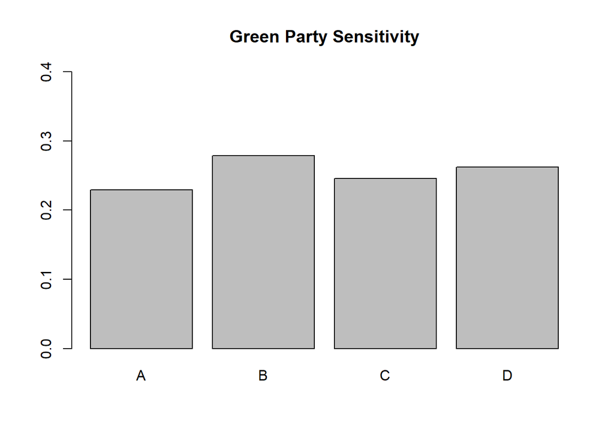

```r
green_sens <- c(
  A = pred_2$cm$byClass["Class: Green Party", "Sensitivity"],
  B = pred_3$cm$byClass["Class: Green Party", "Sensitivity"],
  C = pred_4$cm$byClass["Class: Green Party", "Sensitivity"],
  D = pred_5$cm$byClass["Class: Green Party", "Sensitivity"]
)

barplot(green_sens, main = "Green Party Sensitivity", ylim = c(0, 0.4))
```

```r
params_map <- list(
  A = params_2,  # pred_2
  B = params_3,  # pred_3
  C = params_4,  # pred_4
  D = params_5   # pred_5
)

nrounds_map <- c(
  A = 200,
  B = 200,
  C = 185,
  D = 185
)

R <- 20
set.seed(1)
seeds <- sample(1:10000, R)
green_row <- "Class: Green Party"

run_once <- function(params, dtrain, dtest, nrounds, seed) {
  set.seed(seed)
  out <- train_and_evaluate(params, dtrain, dtest, nrounds = nrounds)
  c(
    Accuracy    = as.numeric(out$cm$overall["Accuracy"]),
    Green_Sens  = as.numeric(out$cm$byClass[green_row, "Sensitivity"])
  )
}

res_list <- lapply(names(nrounds_map), function(m){
  mat <- sapply(seeds, function(s) run_once(params_map[[m]], dtrain, dtest, nrounds_map[[m]], s))
  t(mat) %>% as.data.frame() %>% mutate(model = m)
})

res <- dplyr::bind_rows(res_list)

summary_tbl <- res %>%
  dplyr::group_by(model) %>%
  dplyr::summarise(
    Accuracy_mean   = mean(Accuracy),
    Accuracy_sd     = sd(Accuracy),
    GreenSens_mean  = mean(Green_Sens),
    GreenSens_sd    = sd(Green_Sens),
    .groups = "drop"
  ) %>%
  dplyr::arrange(desc(Accuracy_mean))

summary_tbl
```

| model | Accuracy_mean | Accuracy_sd | GreenSens_mean | GreenSens_sd |
| --- | --- | --- | --- | --- |
| A | 0.5528599 | 0.002207415 | 0.2360656 | 0.01946977 |
| B | 0.5519337 | 0.002350891 | 0.2319672 | 0.02009539 |
| C | 0.5515600 | 0.002360743 | 0.2401639 | 0.02273720 |
| D | 0.5510400 | 0.002988800 | 0.2368852 | 0.02406691 |

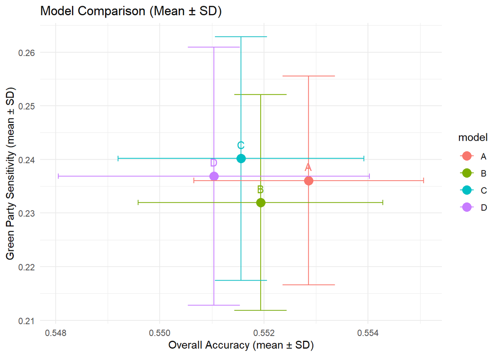

```r
# Scatter plot with error bars (means ± SD)
library(ggplot2)

ggplot(summary_tbl, aes(x = Accuracy_mean, y = GreenSens_mean, color = model)) +
  geom_point(size = 4) +
  geom_errorbar(aes(ymin = GreenSens_mean - GreenSens_sd,
                    ymax = GreenSens_mean + GreenSens_sd),
                width = 0.001) +
  geom_errorbarh(aes(xmin = Accuracy_mean - Accuracy_sd,
                     xmax = Accuracy_mean + Accuracy_sd),
                 height = 0.001) +
  geom_text(aes(label = model), vjust = -1.2, show.legend = FALSE) +
  labs(
    title = "Model Comparison (Mean ± SD)",
    x = "Overall Accuracy (mean ± SD)",
    y = "Green Party Sensitivity (mean ± SD)"
  ) +
  theme_minimal()
```

Across 20 repeated runs, Model A achieved the highest mean overall accuracy (0.553) and the lowest standard deviation (0.00221), indicating both strong performance and high stability. In terms of Green Party sensitivity, Model C had the highest mean value (0.240), but also showed larger variability (SD = 0.0227), which suggests that its advantage in this metric is less consistent across runs.

Models B and D performed slightly worse overall. Model B’s mean accuracy (0.552) was marginally lower than A’s and it had the lowest mean Green Party sensitivity (0.232). Model D not only had the lowest mean accuracy (0.551) but also the largest variability in both accuracy and sensitivity, making it the least stable choice.